# Projet final : ANOVA à Mesures Répétées

Awa Diaw et Mamady I Bérété

2026-03-02

# Préambule

Ce projet s’inscrit dans le cadre d’un TP final du cours d’**ANOVA (Analyse de la variance)**.  
Il porte sur une **ANOVA à mesures répétées à trois facteurs** afin d’évaluer les effets de la variété, du type de terreau et des répétitions sur la croissance des plantes.

Chaque chunk de code peut être affiché ou masqué grâce aux boutons `▼ Afficher / ▲ Masquer`, facilitant la lecture du script et la consultation des résultats.

## Installation des packages

```r
# ── Liste des packages nécessaires ───────────────────────────────────────────
packages <- c(
  "readxl",       # lecture Excel
  "tidyverse",    # dplyr, ggplot2, tidyr, etc.
  "ggpubr",       # visualisation améliorée
  "FactoMineR",   # ACP
  "factoextra",   # visualisation ACP
  "knitr",        # tableau et rendu
  "kableExtra",   # beaux tableaux
  "writexl",      # export Excel
  "janitor",      # nettoyage noms variables
  "rstatix",      # tests statistiques ANOVA, outliers
  "gtsummary",    # tableaux statistiques
  "dplyr",        # manipulation données
  "missMDA",      # imputation NA pour ACP
  "emmeans",      # comparaisons post-hoc
  "lme4",         # modèles linéaires mixtes
  "lmerTest" ,     # ANOVA type III pour LMM
  "patchwork"
)

# ── Installer uniquement les packages manquants ───────────────────────────────
manquants <- packages[!packages %in% installed.packages()[, "Package"]]

if (length(manquants) > 0) {
  message("Installation de : ", paste(manquants, collapse = ", "))
  install.packages(manquants, dependencies = TRUE)
  message("Installation terminée.")
} else {
  message("Tous les packages sont déjà installés.")
}

# Chargement des librairies
# Chargement des librairies
invisible(lapply(packages, library, character.only = TRUE))
```

# Introduction

## Présentation de l’étude

La base mise à notre disposition porte sur des données réelles recueillies dans le cadre d’une `expérimentation agronomique.` Dans cette expérimentation, trois types de terreau ont été utilisés : `Terreau de Manguier (Ma), Terreau de Caïlcédrat (Ca) et Terreau d’Anacarde (An).` Deux variétés de plants ont été semées (`Variété 1 et Variété 2`) et l’expérience est réalisée selon un dispositif à quatre répétitions (`T1 à T4`). Pour chaque combinaison (terreau × variété × répétition), la `hauteur` des plants a été mesurée.

> L’objectif de l’étude est de décrire la croissance des plants selon **terreau** et **variété**, suivre l’évolution sur les **répétitions**, et identifier effets principaux et interactions.

## Brève explication de l’ANOVA à mesures répétées

> - Analyse des mesures répétées sur les mêmes sujets.
> - Sépare variance inter-sujets (différences naturelles : terreau et variété) et variance intra-sujet (effet répétition).
> - Teste les effets principaux et interactions de 3 facteurs : variété × terreau × répétition.
> - Hypothèses à vérifier : normalité, homogénéité des variances, sphéricité (Mauchly).

Dans ce travail, nous réalisons successivement : una analyse exploratoire et descriptive des données (univariée, bivariée et multidimensionnelle) et une analyse inférentielle (anova-MR)

# I. Préparation des données

## 1. Lecture des données

```r
# Importer la base Excel
df_wide <- read_excel("data/dataset.xlsx",sheet = "processed_data")

# Conversion virgule -> point + numérique
df_wide <- df_wide %>%
  mutate(across(starts_with("rep"),
                ~ as.numeric(str_replace(as.character(.), ",", "."))))

# Noms de variables propres
df_wide <- df_wide %>% clean_names()

glimpse(df_wide)                   # structure
```

```
## Rows: 92
## Columns: 7
## $ sujet   <dbl> 1, 2, 3, 4, 5, 6, 7, 8, 9, 10, 11, 12, 13, 14, 15, 16, 17, 18,…
## $ terreau <chr> "Ma", "Ma", "Ma", "Ma", "Ma", "Ma", "Ma", "Ma", "Ma", "Ma", "M…
## $ variete <chr> "Var2", "Var2", "Var2", "Var2", "Var2", "Var2", "Var2", "Var2"…
## $ rep1    <dbl> 43.0, 42.0, 40.0, 46.0, 42.0, 40.0, 32.5, 44.0, 39.3, 42.0, 43…
## $ rep2    <dbl> 37.7, 24.5, 33.5, 36.7, NA, NA, NA, NA, NA, NA, NA, NA, NA, NA…
## $ rep3    <dbl> 29.0, 33.0, 31.5, 25.0, 30.0, 41.0, 33.3, 19.5, 33.0, 28.0, 38…
## $ rep4    <dbl> 36.0, 42.0, 40.0, 36.5, 36.0, 32.5, 29.0, 40.0, 43.5, 44.5, 42…
```

```r
dim(df_wide)                       # dimensions
```

```
## [1] 92  7
```

```r
summary(df_wide)                   # résumé global
```

```
##      sujet         terreau            variete               rep1
##  Min.   : 1.00   Length:92          Length:92          Min.   : 8.50
##  1st Qu.:23.75   Class :character   Class :character   1st Qu.:29.50
##  Median :46.50   Mode  :character   Mode  :character   Median :33.85
##  Mean   :46.50                                         Mean   :33.67
##  3rd Qu.:69.25                                         3rd Qu.:40.38
##  Max.   :92.00                                         Max.   :51.10
##                                                        NA's   :2
##       rep2            rep3            rep4
##  Min.   :13.70   Min.   :11.50   Min.   :19.00
##  1st Qu.:33.00   1st Qu.:25.50   1st Qu.:32.88
##  Median :37.00   Median :30.50   Median :36.50
##  Mean   :35.22   Mean   :29.44   Mean   :36.50
##  3rd Qu.:39.88   3rd Qu.:33.00   3rd Qu.:41.50
##  Max.   :45.00   Max.   :45.50   Max.   :46.00
##  NA's   :38      NA's   :26      NA's   :20
```

```r
colSums(is.na(df_wide))            # valeurs manquantes
```

```
##   sujet terreau variete    rep1    rep2    rep3    rep4
##       0       0       0       2      38      26      20
```

## 2. Conversion en format long

Les données ont été initialement fournies au `format large,` où chaque ligne correspond à une plante (Sujet) et les mesures répétées de hauteur sont stockées dans des colonnes distinctes (Rep1, Rep2, Rep3, Rep4).

Cependant, pour réaliser une ANOVA à mesures répétées ou un modèle mixte, les données `doivent être structurées au format long,` dans lequel chaque ligne correspond à une observation unique (`une mesure de hauteur pour un sujet donné à une répétition donnée`).

```r
# Passage en long : NA conservés
df_long <- df_wide %>%
  pivot_longer(
    cols = starts_with("rep"),
    names_to = "repetition",
    values_to = "hauteur",
    values_drop_na = FALSE
  ) %>%
  select(sujet,repetition, terreau, variete, hauteur)

# Ordonner les répétitions
df_long$repetition <- factor(df_long$repetition,
                             levels = c("rep1", "rep2", "rep3", "rep4"))

#  Enregistrer en Excel
write_xlsx(df_long, "data/dataset_long.xlsx")
```

## 3. Détection et traitement des valeurs extrêmes

Les outliers ont été recherchés par combinaison `**terreau × variété**`, afin de garantir des groupes suffisamment grands.

```r
# Détection des outliers par répétition
outliers <- df_long %>%
  group_by(terreau, variete) %>%
  identify_outliers(hauteur)

outliers
```

| terreau | variete | sujet | repetition | hauteur | is.outlier | is.extreme |
| --- | --- | --- | --- | --- | --- | --- |
| An | Var2 | 70 | rep2 | 13.7 | TRUE | FALSE |
| An | Var2 | 72 | rep4 | 20.0 | TRUE | FALSE |
| An | Var2 | 75 | rep3 | 12.5 | TRUE | FALSE |
| Ca | Var1 | 51 | rep3 | 12.5 | TRUE | FALSE |
| Ca | Var1 | 53 | rep3 | 11.5 | TRUE | FALSE |
| Ma | Var1 | 17 | rep3 | 12.5 | TRUE | FALSE |
| Ma | Var1 | 19 | rep3 | 11.5 | TRUE | FALSE |

## 4. Winsorisation des outliers

```r
# Fonction de winsorisation 1% - 99%
winsorize <- function(x, probs = c(0.01, 0.99)) {
  qs <- quantile(x, probs = probs, na.rm = TRUE)
  x[x < qs[1]] <- qs[1]
  x[x > qs[2]] <- qs[2]
  return(x)
}
data <- df_long %>%
  group_by(terreau, variete) %>%
  mutate(hauteur_wins = winsorize(hauteur, probs = c(0.01, 0.99))) %>%
  ungroup()
```

# II. Exploration des données

## 1. Statistiques descriptives univariées

```r
theme_gtsummary_compact()
data %>%
  select(hauteur, terreau, variete, repetition) %>%
  tbl_summary(
    statistic = list(
      all_continuous() ~ "{mean} ± {sd} | médiane = {median} | [{min} ; {max}]",
      all_categorical() ~ "{n} ({p}%)"
    ),
    digits = all_continuous() ~ 2,
    label = list(
      hauteur ~ "Hauteur des plantes (cm)",
      terreau ~ "Type de terreau",
      variete ~ "Variété",
      repetition ~ "Répétition"
    )
  ) %>%
  bold_labels() %>%
  modify_header(label ~ "**Variables**") %>%
  modify_caption("**Tableau 1.** Statistiques descriptives des plants selon les traitements") %>%
  modify_footnote(
    all_stat_cols() ~ "Les valeurs sont présentées sous forme : moyenne ± écart-type | médiane | [min ; max]."
  )
```

**Tableau 1.** Statistiques descriptives des plants selon les traitements

| **Variables** | **N = 368**<sup>1</sup> |
| --- | --- |
| Hauteur des plantes (cm) | 33.70 ± 8.10 \| médiane = 34.40 \| [8.50 ; 51.10] |
| Unknown | 86 |
| Type de terreau |  |
| An | 96 (26%) |
| Ca | 136 (37%) |
| Ma | 136 (37%) |
| Variété |  |
| Var1 | 188 (51%) |
| Var2 | 180 (49%) |
| Répétition |  |
| rep1 | 92 (25%) |
| rep2 | 92 (25%) |
| rep3 | 92 (25%) |
| rep4 | 92 (25%) |

<sup>1</sup> Les valeurs sont présentées sous forme : moyenne ± écart-type | médiane | [min ; max].

La hauteur moyenne des plants est de 33,7 cm (écart-type 8,1 cm), avec une médiane proche (34,4 cm), indiquant une distribution globalement symétrique. Les plants sont répartis presque équitablement entre les variétés Var1 (51%) et Var2 (49%). Concernant le type de terreau, les effectifs sont légèrement déséquilibrés : Ca (37%), Ma (37%), An (26%). La distribution des mesures selon les répétitions (T1–T4) est homogène, ce qui permet de tester l’effet du temps dans les analyses de mesures répétées. Le tableau inclut 86 valeurs inconnues.

### Distribution globale de la hauteur des plantes

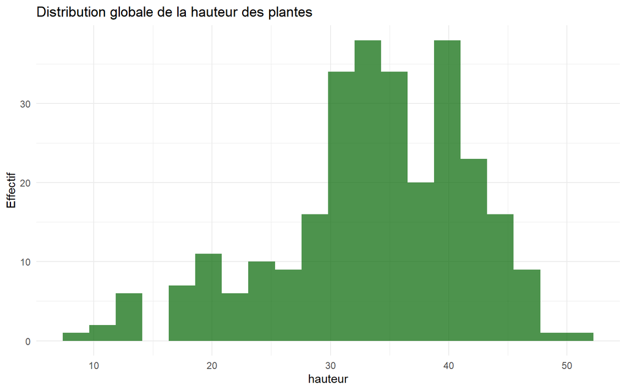

```r
ggplot(data, aes(x = hauteur)) +
  geom_histogram(bins = 20, fill = "darkgreen", alpha = 0.7) +
  labs(title = "Distribution globale de la hauteur des plantes",
       x = "hauteur", y = "Effectif") +
  theme_minimal()
```

La hauteur des plantes est globalement centrée autour de 34–36 cm, avec une distribution étalée à gauche et quelques valeurs extrêmes visibles sur l’histogramme.

## 2. Statistiques descriptives bivariées

### Box Plot de la hauteur pour chaque répétition

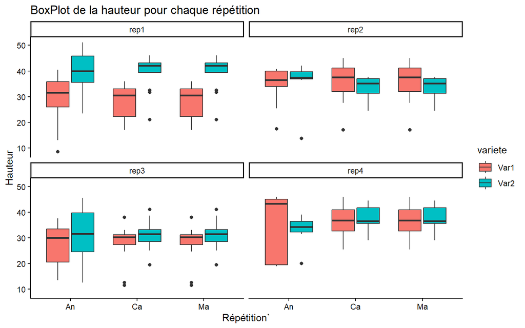

```r
ggplot(data,aes(x=terreau,y=hauteur,fill=variete))+geom_boxplot()+
ggtitle("BoxPlot de la hauteur pour chaque répétition")+
facet_wrap(~repetition)+
xlab("Répétition`")+
ylab("Hauteur")+
theme_classic()
```

Les hauteurs ne sont pas constantes d’une répétition à l’autre : la position des médianes et l’étendue des boîtes varient au fil du temps, ce qui suggère une évolution des mesures entre Rep1, Rep2, Rep3 et Rep4. *Les valeurs “aberrantes” visibles sur les boxplots par répétition ne sont pas des erreurs : elles reflètent la variabilité réelle et le faible effectif par sous-groupe. La winsorisation a été appliquée au niveau terreau × variété, pas pour chaque répétition.*

### Courbes de croissance (évolution temporelle)

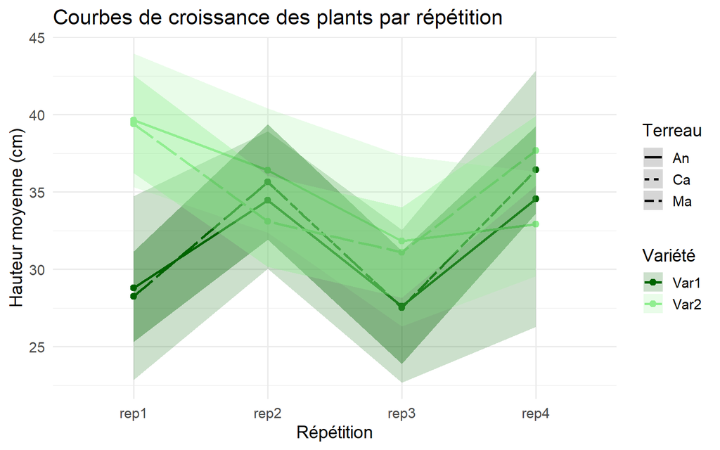

```r
# Calcul des statistiques par groupe
summary_data <- data %>%
  group_by(repetition, terreau, variete) %>%
  summarise(
    mean_hauteur = mean(hauteur, na.rm = TRUE),
    sd_hauteur   = sd(hauteur, na.rm = TRUE),
    n            = n(),
    se_hauteur   = sd_hauteur / sqrt(n),
    ci_lower     = mean_hauteur - 1.96 * se_hauteur,
    ci_upper     = mean_hauteur + 1.96 * se_hauteur
  )

# Graphique
ggplot(summary_data, aes(x = repetition, y = mean_hauteur,
                         group = interaction(terreau, variete),
                         color = variete, linetype = terreau)) +
  geom_line(size = 1) +                        # ligne moyenne
  geom_point(size = 2) +                       # points
  geom_ribbon(aes(ymin = ci_lower, ymax = ci_upper, fill = variete),
              alpha = 0.2, color = NA) +      # bande d'erreur
  labs(
    title = "Courbes de croissance des plants par répétition",
    x = "Répétition",
    y = "Hauteur moyenne (cm)",
    color = "Variété",
    fill = "Variété",
    linetype = "Terreau"
  ) +
  theme_minimal(base_size = 14) +
  scale_color_manual(values = c("Var1" = "darkgreen", "Var2" = "lightgreen")) +
  scale_fill_manual(values = c("Var1" = "darkgreen", "Var2" = "lightgreen"))
```

*Le graphique des profils moyens montre que la hauteur des plants varie selon la répétition, avec une baisse autour de Rep3. Les trajectoires des deux variétés ne sont pas parallèles : l’écart entre Var1 et Var2 change au fil du temps, suggérant une interaction possible variété × répétition. Les profils sont globalement similaires entre les trois types de terreau, indiquant que l’effet visuel du terreau semble modéré.*

## 3. Analyse exploratoire multivariée

L’`Analyse en Composantes Principales (ACP)` est utilisée ici comme outil exploratoire complémentaire à l’ANOVA. L’ACP facilite la projection des répétitions, l’identification de regroupements naturels et la comparaison des traitements, fournissant ainsi une synthèse graphique et statistique des profils de croissance des plantes avant les tests formels.

### Préparation

```r
data_acp <- df_wide

## Sélection des colonnes numériques pour l'ACP
num_vars <- data_acp[, c("rep1","rep2","rep3","rep4")]

# Colonnes metadata pour terreau et variete
meta <- data_acp[, c("terreau","variete")]
print(meta)
```

```
## # A tibble: 92 × 2
##    terreau variete
##    <chr>   <chr>
##  1 Ma      Var2
##  2 Ma      Var2
##  3 Ma      Var2
##  4 Ma      Var2
##  5 Ma      Var2
##  6 Ma      Var2
##  7 Ma      Var2
##  8 Ma      Var2
##  9 Ma      Var2
## 10 Ma      Var2
## # ℹ 82 more rows
```

### Imputation des NA

```r
# imputePCA remplace les NA par la valeur estimée par PCA
impute <- imputePCA(num_vars, ncp = 2)
data_impute <- impute$completeObs

# Vérifier que tout est bien imputé
sum(is.na(data_impute))  # doit être 0
```

```
## [1] 0
```

### Calcul de l’ACP

```r
res_acp <- PCA(data_impute, scale.unit = TRUE, graph = FALSE)
```

### Valeurs propres et variance expliquée

```r
## Valeurs propres et variance expliquée
eig <- get_eigenvalue(res_acp)
kable(eig, caption = "Valeurs propres et variance expliquée par les composantes",
      digits = 3, align = "c") %>%
  kable_styling(bootstrap_options = c("striped","hover"), full_width = FALSE)
```

Valeurs propres et variance expliquée par les composantes

|  | eigenvalue | variance.percent | cumulative.variance.percent |
| --- | --- | --- | --- |
| Dim.1 | 1.435 | 35.877 | 35.877 |
| Dim.2 | 1.143 | 28.582 | 64.459 |
| Dim.3 | 0.806 | 20.152 | 84.611 |
| Dim.4 | 0.616 | 15.389 | 100.000 |

```r
eig
```

```
##       eigenvalue variance.percent cumulative.variance.percent
## Dim.1  1.4350820         35.87705                    35.87705
## Dim.2  1.1432801         28.58200                    64.45905
## Dim.3  0.8060871         20.15218                    84.61123
## Dim.4  0.6155508         15.38877                   100.00000
```

### Scree plot

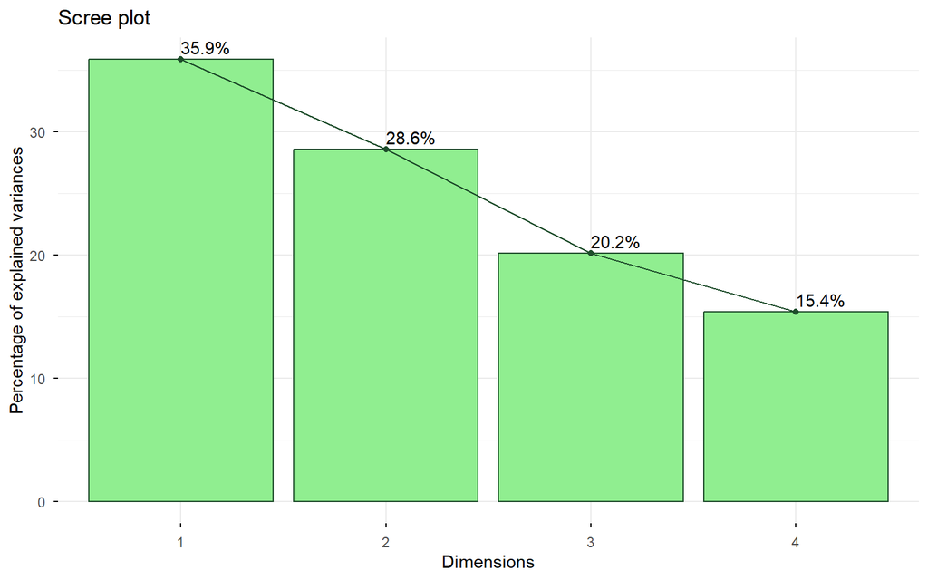

Variance expliquée par composante (Scree plot)

```r
factoextra::fviz_eig(res_acp, addlabels = TRUE,
   barfill = "lightgreen", barcolor = "#1e4d2b", linecolor = "#1e4d2b")
```

### Projection des individus

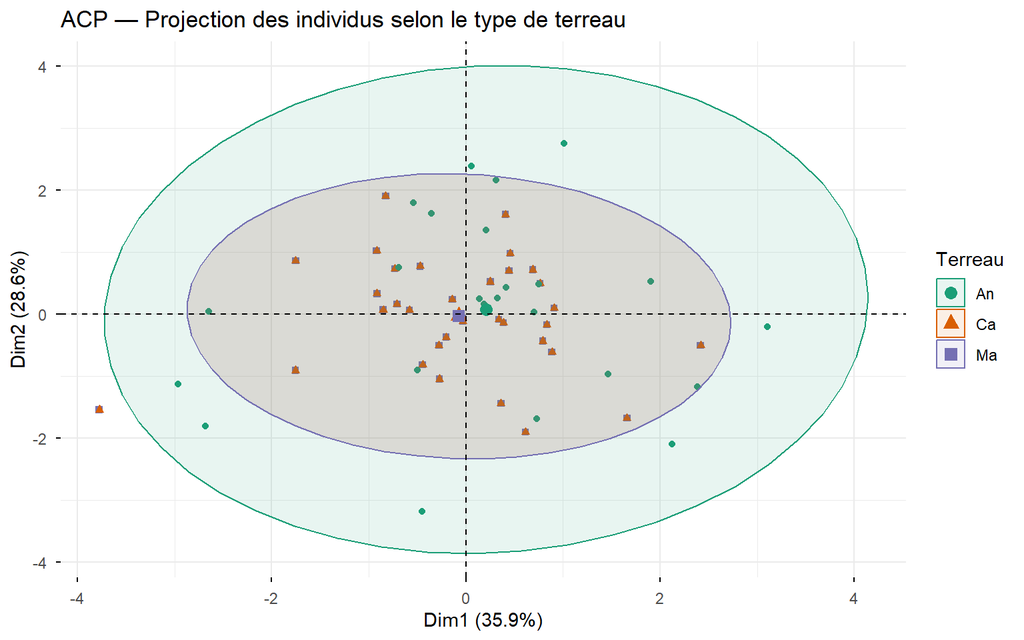

```r
# Assurer que meta correspond exactement aux lignes de data_impute
meta <- meta[1:nrow(data_impute), , drop = FALSE]
meta$terreau <- factor(meta$terreau)  # facteur pour couleur

fviz_pca_ind(res_acp,
             geom.ind = "point",
             habillage = meta$terreau,    # couleur selon terreau
             addEllipses = TRUE,          # ellipses par groupe
             ellipse.level = 0.95,
             palette = "Dark2",
             legend.title = "Terreau",
             title = "ACP — Projection des individus selon le type de terreau")
```

### Projection des variables (repetition de mesure)

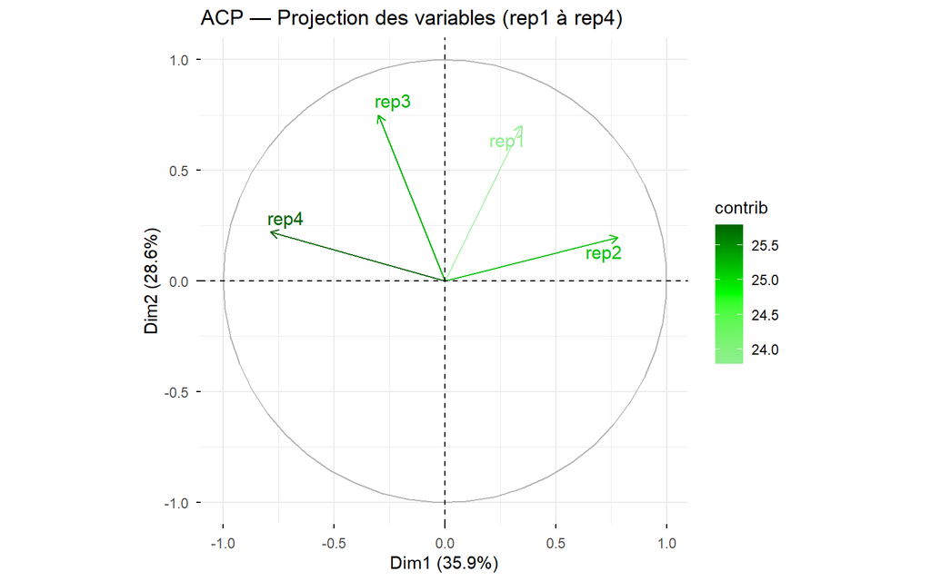

```r
fviz_pca_var(res_acp,
             col.var = "contrib",          # couleur selon contribution
             gradient.cols = c("lightgreen","green","darkgreen"),
             repel = TRUE,
             title = "ACP — Projection des variables (rep1 à rep4)")
```

```r
length(meta$terreau)
```

```
## [1] 92
```

```r
n_active <- nrow(res_acp$ind$coord)
```

L’ACP descriptive réalisée sur les données de croissance montre que les deux premières composantes expliquent 64,5 % de la variance totale. La projection des individus selon le type de terreau ne met pas en évidence de séparation nette entre les groupes, indiquant une forte variabilité intra-terreau. Le cercle des corrélations des répétitions met en évidence des profils différenciés entre rep1 à rep4, certaines répétitions étant corrélées entre elles (rep1 et rep3), tandis que d’autres s’opposent sur la première composante (rep2 et rep4). Ces résultats suggèrent une hétérogénéité entre répétitions, justifiant la prise en compte de l’effet “répétition” dans l’analyse inférentielle ultérieure.

Synthèse de l’analyse descriptive

L’analyse descriptive met en évidence l’ordre de grandeur et la dispersion des hauteurs observées. Les comparaisons bivariées et les profils moyens suggèrent des différences de croissance selon la variété, avec des trajectoires temporelles non parallèles, tandis que l’effet du terreau apparaît visuellement plus modéré. L’ACP met en évidence des structures globales et une hétérogénéité entre répétitions, ce qui motive l’usage d’une ANOVA à mesures répétées pour tester formellement les effets et interactions.

# III. Analyse inférentielle

> Cette section vise à étudier l’effet des facteurs **terreau** et **variété** sur la **hauteur des plantes** au fil des **répétitions**. Nous utiliserons l’ANOVA à mesures répétées et un modèle linéaire mixte pour quantifier les effets et interactions significatives.

## 1. Types d’ANOVA et choix du modèle

> Avant de lancer l’analyse, il est important de choisir le modèle adapté à la structure de nos données : mesures répétées, facteurs inter- et intra-sujets, présence de NA. Le tableau ci-dessous résume les options principales.

| Type d’ANOVA | Structure | Facteurs | Corrélation intra-sujet | Gestion des NA | Hypothèses principales | Usage typique |
| --- | --- | --- | --- | --- | --- | --- |
| ANOVA classique | Groupes indépendants | Inter-sujets | ❌ | ❌ | Normalité, homogénéité des variances, indépendance | Comparer des groupes distincts |
| ANOVA à mesures répétées | Même sujet, plusieurs mesures | Intra-sujet (temps) | ✅ | ❌ | Normalité des résidus, sphéricité | Données longitudinales complètes (sans NA) |
| ANOVA mixte (split-plot) | Groupes + mesures répétées | Inter + Intra | ✅ | ❌ | Normalité des résidus, homogénéité, sphéricité | Plans combinant traitements et temps |
| Modèle linéaire mixte | Déséquilibré, données hiérarchiques | Inter + Intra + aléatoires | ✅ | ✅ | Normalité des résidus (effets aléatoires gaussiens) | Données non équilibrées, corrélées, avec NA |

> Pour ce jeu de données, le **modèle linéaire mixte** est justifié pour tenir compte de la variabilité individuelle et des mesures répétées, surtout comme des NA sont présents.

## 2. Vérification des hypothèses

### Normalité

> L’hypothèse de normalité est testée par cellule (Terreau × Variété × Répétition) avec Shapiro-Wilk et vérifiée graphiquement via QQ-plots pour chaque cellule du plan.

```r
data %>%
  group_by(terreau, variete, repetition) %>%
  shapiro_test(hauteur)
```

| repetition | terreau | variete | variable | statistic | p |
| --- | --- | --- | --- | --- | --- |
| rep1 | An | Var1 | hauteur | 0.8655698 | 6.797601e-02 |
| rep2 | An | Var1 | hauteur | 0.8058315 | 1.706690e-02 |
| rep3 | An | Var1 | hauteur | 0.9390122 | 5.715396e-01 |
| rep4 | An | Var1 | hauteur | 0.7397196 | 2.383802e-02 |
| rep1 | An | Var2 | hauteur | 0.9579469 | 7.217356e-01 |
| rep2 | An | Var2 | hauteur | 0.5652011 | 5.581759e-05 |
| rep3 | An | Var2 | hauteur | 0.9605435 | 7.784538e-01 |
| rep4 | An | Var2 | hauteur | 0.8305102 | 8.091460e-02 |
| rep1 | Ca | Var1 | hauteur | 0.8850186 | 3.173343e-02 |
| rep2 | Ca | Var1 | hauteur | 0.9183889 | 2.728504e-01 |

[output cut: 14 more lines]

Le test de Shapiro-Wilk appliqué par cellule (Terreau × Variété × Répétition) met en évidence quelques déviations ponctuelles à la normalité (p < 0,05), principalement pour la variété Var1 à certaines répétitions. Cependant, plusieurs cellules ont des effectifs faibles (parfois n ≤ 10), rendant le test instable et très sensible.

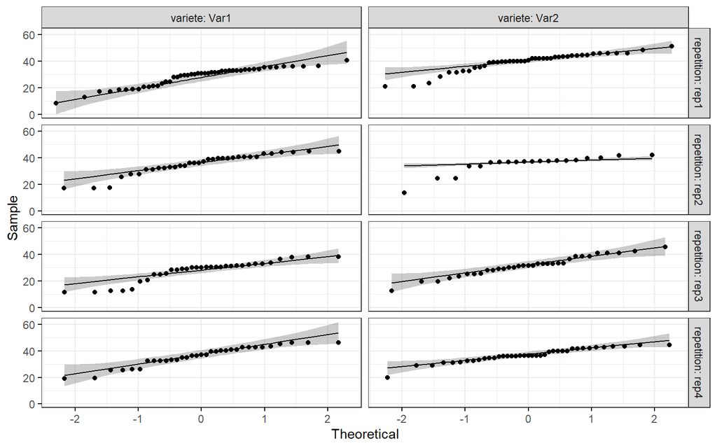

```r
ggqqplot(data, "hauteur", ggtheme = theme_bw()) +
  facet_grid(repetition ~ variete, labeller = "label_both")
```

L’évaluation graphique via les QQ-plots suggère une normalité globalement acceptable des résidus.

### Homogénéité des variances

> Test de Levene par répétition pour vérifier l’égalité des variances entre groupes.

```r
data %>%
  group_by(repetition) %>%
  levene_test(hauteur ~ terreau*variete)
```

| repetition | df1 | df2 | statistic | p |
| --- | --- | --- | --- | --- |
| rep1 | 5 | 84 | 0.5648604 | 0.72663784 |
| rep2 | 5 | 48 | 0.4699164 | 0.79675766 |
| rep3 | 5 | 60 | 0.8768248 | 0.50218847 |
| rep4 | 5 | 66 | 2.0847351 | 0.07831081 |

Le test de Levene (centré sur la médiane) a été appliqué séparément à chaque répétition afin d’évaluer l’hypothèse d’homogénéité des variances entre les groupes définis par les facteurs terreau et variété. Les résultats indiquent que l’hypothèse d’égalité des variances n’est pas rejetée pour l’ensemble des répétitions : rep1 (p = 0,727), rep2 (p = 0,797), rep3 (p = 0,502) et rep4 (p = 0,078).

Ainsi, pour chacune des répétitions, aucune hétéroscédasticité significative n’est détectée au seuil de 5 %. Bien que la p-value associée à la répétition 4 soit relativement proche du seuil de significativité, elle demeure non significative. L’hypothèse d’homogénéité des variances peut donc être considérée comme raisonnablement satisfaite dans l’ensemble du dispositif expérimental.

### Sphéricité

> L’hypothèse de sphéricité stipule que les variances des différences entre les niveaux du facteur intra-sujets (ici la répétition des mesures) sont égales.

Cette hypothèse est spécifique aux plans à mesures répétées et est classiquement évaluée à l’aide du test de Mauchly. En cas de violation de cette hypothèse (p < 0,05), des corrections des degrés de liberté telles que Greenhouse–Geisser sont recommandées afin d’éviter une inflation du risque de première espèce. Dans cette étude, l’hypothèse de sphéricité a été testée automatiquement dans le cadre de l’ANOVA mixte (terreau et variété comme facteurs inter-sujets, répétition comme facteur intra-sujets) à l’aide de la fonction anova_test() du package rstatix. Les corrections de sphéricité ont été appliquées automatiquement lorsque nécessaire, via la fonction get_anova_table() (Greenhouse–Geisser).

```r
res.aov <- anova_test(
  data = data, dv = hauteur, wid = sujet,
  within = repetition, between = c(terreau, variete)
)
get_anova_table(res.aov)
```

|  | Effect | DFn | DFd | F | p | p<.05 | ges |
| --- | --- | --- | --- | --- | --- | --- | --- |
| 1 | terreau | 2.00 | 38.00 | 1.231 | 3.03e-01 |  | 0.012000 |
| 2 | variete | 1.00 | 38.00 | 14.190 | 5.60e-04 | * | 0.068000 |
| 3 | repetition | 2.38 | 90.55 | 7.987 | 2.92e-04 | * | 0.145000 |
| 4 | terreau:variete | 2.00 | 38.00 | 0.039 | 9.62e-01 |  | 0.000398 |
| 5 | terreau:repetition | 4.77 | 90.55 | 0.209 | 9.53e-01 |  | 0.009000 |
| 6 | variete:repetition | 2.38 | 90.55 | 9.149 | 9.62e-05 | * | 0.162000 |
| 7 | terreau:variete:repetition | 4.77 | 90.55 | 0.127 | 9.83e-01 |  | 0.005000 |

L’hypothèse de sphéricité a été testée automatiquement et les corrections Greenhouse–Geisser ont été appliquées lorsque nécessaire. Cela garantit que les degrés de liberté intra-sujets sont ajustés pour éviter une inflation du risque de type I (conclure qu’un effet est significatif alors qu’il ne l’est pas vraiment).

## 3. Résultats de l’anova

### Effets principaux

- Terreau : non significatif (p = 0,303, ges = 0,012) : le type de terreau n’influence pas significativement la hauteur.
- Variété : significatif (p = 5,6e-04, ges = 0,068) : la hauteur varie selon la variété.
- Répétition : significatif (p = 2,92e-04, ges = 0,145) : la hauteur évolue au fil des répétitions.

### Interactions

- Varieté × répétition : significative (p = 9,62e-05, ges = 0,162) : la différence entre variétés dépend du moment de mesure.
- Autres interactions (terreau × variété, terreau × répétition, terreau × variété × répétition) : non significatives : pas d’effet combiné notable de ces facteurs.

> L’effet du temps (répétitions) et la variété influencent la croissance des plantes, tandis que le terreau seul n’a pas d’effet majeur. L’interaction variété × répétition suggère que certaines variétés croissent différemment selon les moments de mesure.

## 4. Analyse post-hoc

Après l’ANOVA à mesures répétées, certaines interactions ou effets principaux sont significatifs (ex. variete, repetition, variete × repetition). `L’ANOVA globale indique seulement qu’il y a une différence quelque part, mais ne précise pas quels niveaux diffèrent entre eux.`

### Comparaisons par paires

> Les effets principaux et interactions sont détaillés par comparaisons multiples avec correction Bonferroni pour limiter les erreurs de type I.

Les Comparaisons par paires (pairwise_t_test) permettent d’`identifier quelles variétés diffèrent statistiquement dans chaque combinaison` répétition × terreau. La correction Bonferroni `ajuste le seuil de significativité` pour limiter le risque d’erreur de type I, qui augmente lorsqu’on fait plusieurs tests simultanément.

```r
pwc <- data %>%
  group_by(repetition, terreau) %>%
  pairwise_t_test(hauteur ~ variete, p.adjust.method = "bonferroni")
pwc
```

|  | repetition | terreau | .y. | group1 | group2 | n1 | n2 | p | p.signif | p.adj | p.adj.signif |
| --- | --- | --- | --- | --- | --- | --- | --- | --- | --- | --- | --- |
| 1 | rep1 | An | hauteur | Var1 | Var2 | 11 | 13 | 7.43e-03 | ** | 7.43e-03 | ** |
| 2 | rep1 | Ca | hauteur | Var1 | Var2 | 18 | 16 | 2.25e-05 | **** | 2.25e-05 | **** |
| 3 | rep1 | Ma | hauteur | Var1 | Var2 | 18 | 16 | 2.25e-05 | **** | 2.25e-05 | **** |
| 4 | rep2 | An | hauteur | Var1 | Var2 | 11 | 13 | 5.54e-01 | ns | 5.54e-01 | ns |
| 5 | rep2 | Ca | hauteur | Var1 | Var2 | 18 | 16 | 5.74e-01 | ns | 5.74e-01 | ns |
| 6 | rep2 | Ma | hauteur | Var1 | Var2 | 18 | 16 | 5.74e-01 | ns | 5.74e-01 | ns |
| 7 | rep3 | An | hauteur | Var1 | Var2 | 11 | 13 | 3.31e-01 | ns | 3.31e-01 | ns |
| 8 | rep3 | Ca | hauteur | Var1 | Var2 | 18 | 16 | 2.40e-01 | ns | 2.40e-01 | ns |
| 9 | rep3 | Ma | hauteur | Var1 | Var2 | 18 | 16 | 2.40e-01 | ns | 2.40e-01 | ns |
| 10 | rep4 | An | hauteur | Var1 | Var2 | 11 | 13 | 7.88e-01 | ns | 7.88e-01 | ns |

[output cut: 2 more lines]

- `Répétition 1 (rep1)` :
  - Toutes les combinaisons de terreau (An, Ca, Ma) montrent une **différence significative entre Var1 et Var2**.
  - p-values ajustées Bonferroni : An = 0.0074 (**), Ca = 2.25e-05 (), Ma = 2.25e-05 (****)
  - **Interprétation** : Var2 est significativement plus haute que Var1 à rep1 pour tous les types de terreau.
- `Répétitions 2 à 4 (rep2, rep3, rep4)` :
  - Aucune différence significative entre Var1 et Var2 pour aucun terreau (p.adj > 0.05, ns).
  - **Interprétation** : À partir de rep2, les hauteurs des deux variétés se rapprochent, la différence initiale observée à rep1 disparaît.
- L’effet de la **variété sur la hauteur** est **fort au début de l’expérience (rep1)**, mais **s’estompe au fil des répétitions**, ce qui correspond bien à l’interaction significative **variete × repetition** observée dans l’ANOVA.
- Le type de **terreau n’influence pas la différence entre Var1 et Var2**, puisque la tendance est la même pour An, Ca et Ma.

## 5. Modèle linéaire mixte

> Pour tenir compte à la fois de la répétition et de la variabilité individuelle, nous ajustons un LLM avec effet aléatoire sur les sujets.

L’ANOVA classique ou à mesures répétées suppose souvent des données équilibrées et pas de valeurs manquantes, et peut être sensible aux petites déviations.

Le LMM permet - d’inclure les répétitions comme facteur intra-sujet et la variabilité individuelle des plantes comme effet aléatoire ((1|sujet)) ; - de gérer les données déséquilibrées et les NA ; - de produire des estimations plus robustes et de confirmer les résultats de l’ANOVA globale.

> En résumé, le LMM est une version plus flexible et fiable de l’ANOVA à mesures répétées pour des données expérimentales réelles avec répétitions et variabilité individuelle.

```r
mod <- lmer(hauteur ~ terreau*variete*repetition + (1|sujet), data = data)
anova(mod, type = 3)
```

|  | Sum Sq | Mean Sq | NumDF | DenDF | F value | Pr(>F) |
| --- | --- | --- | --- | --- | --- | --- |
| terreau | 6.358696 | 3.179348 | 2 | 258 | 0.06147991 | 9.403856e-01 |
| variete | 731.211082 | 731.211082 | 1 | 258 | 14.13962547 | 2.100214e-04 |
| repetition | 1504.656289 | 501.552096 | 3 | 258 | 9.69864786 | 4.359988e-06 |
| terreau:variete | 2.999031 | 1.499516 | 2 | 258 | 0.02899654 | 9.714230e-01 |
| terreau:repetition | 123.096622 | 20.516104 | 6 | 258 | 0.39672542 | 8.808131e-01 |
| variete:repetition | 1532.886916 | 510.962305 | 3 | 258 | 9.88061560 | 3.439015e-06 |
| terreau:variete:repetition | 75.653082 | 12.608847 | 6 | 258 | 0.24382067 | 9.614581e-01 |

### Résultats du LMM

- Effets principaux :
- Effet du type de terreau : F(2, 258) = 0.062, p = 0.94 → non significatif. Interprétation : le type de terreau n’a pas d’effet mesurable sur la hauteur des plantes dans cet échantillon.
- Effet de la variété : F(1, 258) = 14.14, p = 0.00021 → hautement significatif (* )**. Interprétation : les différentes variétés présentent des hauteurs moyennes significativement différentes.
- Effet de la répétition (mesure dans le temps) : F(3, 258) = 9.70, p ≈ 4.36e-06 → hautement significatif (* )**. Interprétation : la hauteur des plantes varie significativement au fil des répétitions.
- Interactions
- variete × repetition : F(3, 258) = 9.88, p ≈ 3.44e-06 → significatif (* )**. L’effet de la variété dépend du moment de mesure : certaines variétés croissent plus vite ou plus lentement à différentes répétitions.
- terreau × variete, terreau × repetition, terreau × variete × repetition : p > 0.88 → non significatives. Il n’y a pas d’effet combiné du terreau avec la variété ou les répétitions sur la hauteur.

La variété et le temps (répétition) sont les principaux facteurs qui influencent la hauteur. Le terreau n’a pas d’impact significatif, ni en effet principal ni en interaction. L’interaction significative variété × répétition indique que les trajectoires de croissance diffèrent selon la variété au fil du temps.

> En résumé : le modèle confirme les conclusions de l’ANOVA classique et souligne l’importance de suivre la croissance par répétition pour chaque variété.

Synthèse de l’analyse inférentielle

L’ANOVA à mesures répétées et le modèle linéaire mixte montrent que : - Variété et répétition (temps) influencent significativement la hauteur des plantes. - L’interaction variété × répétition est significative : la différence de croissance entre variétés dépend du moment de mesure. - Le type de terreau n’a pas d’effet significatif, ni seul ni en interaction avec les autres facteurs. - Les tests post-hoc (comparaisons par paires avec correction Bonferroni) confirment que certaines variétés diffèrent significativement au sein de répétitions et de terreaux spécifiques. - L’utilisation du modèle linéaire mixte permet de tenir compte de la variabilité individuelle des sujets et confirme les effets observés, tout en offrant une approche robuste face aux données déséquilibrées.